# Data 605 - Assignment 12

Leticia Salazar

4/11/2022

$~$

### Regression Analysis

$~$

#### The attached who.csv dataset contains real-world data from 2008. The variables included following:

| Country | name of the country |
| --- | --- |
| LifeExp | average life expectancy for the country in years |
| InfantSurvival | proportion of those surviving to one year or more |
| Under5Survival | proportion of those surviving to five years or more |
| TBFree | proportion of the population without TB. |
| PropMD | proportion of the population who are MDs |
| PropRN | proportion of the population who are RNs |
| PersExp | mean personal expenditures on healthcare in US dollars at average exchange rate |
| GovtExp | mean government expenditures per capita on healthcare, US dollars at average exchange rate |
| TotExp | sum of personal and government expenditures. |

$~$

```r
# Import libraries
library(tidyverse)
library(expm)
```

```r
# Load Data
who <- read.csv('https://raw.githubusercontent.com/letisalba/Data-605/main/Week-12/who.csv', header = TRUE)
head(who)
```

```
##               Country LifeExp InfantSurvival Under5Survival  TBFree      PropMD
## 1         Afghanistan      42          0.835          0.743 0.99769 0.000228841
## 2             Albania      71          0.985          0.983 0.99974 0.001143127
## 3             Algeria      71          0.967          0.962 0.99944 0.001060478
## 4             Andorra      82          0.997          0.996 0.99983 0.003297297
## 5              Angola      41          0.846          0.740 0.99656 0.000070400
## 6 Antigua and Barbuda      73          0.990          0.989 0.99991 0.000142857
##        PropRN PersExp GovtExp TotExp
## 1 0.000572294      20      92    112
## 2 0.004614439     169    3128   3297
## 3 0.002091362     108    5184   5292
## 4 0.003500000    2589  169725 172314
## 5 0.001146162      36    1620   1656
## 6 0.002773810     503   12543  13046
```

$~$

```r
# glimpse of data
glimpse(who)
```

```
## Rows: 190
## Columns: 10
## $ Country        <chr> "Afghanistan", "Albania", "Algeria", "Andorra", "Angola…
## $ LifeExp        <int> 42, 71, 71, 82, 41, 73, 75, 69, 82, 80, 64, 74, 75, 63,…
## $ InfantSurvival <dbl> 0.835, 0.985, 0.967, 0.997, 0.846, 0.990, 0.986, 0.979,…
## $ Under5Survival <dbl> 0.743, 0.983, 0.962, 0.996, 0.740, 0.989, 0.983, 0.976,…
## $ TBFree         <dbl> 0.99769, 0.99974, 0.99944, 0.99983, 0.99656, 0.99991, 0…
## $ PropMD         <dbl> 0.000228841, 0.001143127, 0.001060478, 0.003297297, 0.0…
## $ PropRN         <dbl> 0.000572294, 0.004614439, 0.002091362, 0.003500000, 0.0…
## $ PersExp        <int> 20, 169, 108, 2589, 36, 503, 484, 88, 3181, 3788, 62, 1…
## $ GovtExp        <int> 92, 3128, 5184, 169725, 1620, 12543, 19170, 1856, 18761…
## $ TotExp         <int> 112, 3297, 5292, 172314, 1656, 13046, 19654, 1944, 1907…
```

```r
# summary of data
summary(who)
```

```
##    Country             LifeExp      InfantSurvival   Under5Survival
##  Length:190         Min.   :40.00   Min.   :0.8350   Min.   :0.7310
##  Class :character   1st Qu.:61.25   1st Qu.:0.9433   1st Qu.:0.9253
##  Mode  :character   Median :70.00   Median :0.9785   Median :0.9745
##                     Mean   :67.38   Mean   :0.9624   Mean   :0.9459
##                     3rd Qu.:75.00   3rd Qu.:0.9910   3rd Qu.:0.9900
##                     Max.   :83.00   Max.   :0.9980   Max.   :0.9970
##      TBFree           PropMD              PropRN             PersExp
##  Min.   :0.9870   Min.   :0.0000196   Min.   :0.0000883   Min.   :   3.00
##  1st Qu.:0.9969   1st Qu.:0.0002444   1st Qu.:0.0008455   1st Qu.:  36.25
##  Median :0.9992   Median :0.0010474   Median :0.0027584   Median : 199.50
##  Mean   :0.9980   Mean   :0.0017954   Mean   :0.0041336   Mean   : 742.00
##  3rd Qu.:0.9998   3rd Qu.:0.0024584   3rd Qu.:0.0057164   3rd Qu.: 515.25
##  Max.   :1.0000   Max.   :0.0351290   Max.   :0.0708387   Max.   :6350.00
##     GovtExp             TotExp
##  Min.   :    10.0   Min.   :    13
##  1st Qu.:   559.5   1st Qu.:   584
##  Median :  5385.0   Median :  5541
##  Mean   : 40953.5   Mean   : 41696
##  3rd Qu.: 25680.2   3rd Qu.: 26331
##  Max.   :476420.0   Max.   :482750
```

$~$

#### 1. Provide a scatterplot of `LifeExp ~ TotExp`, and run simple linear regression. Do not transform the variables. Provide and interpret the `F statistics`, `R^2`, `standard error`, and `p-values` only. Discuss whether the assumptions of simple linear regression met.

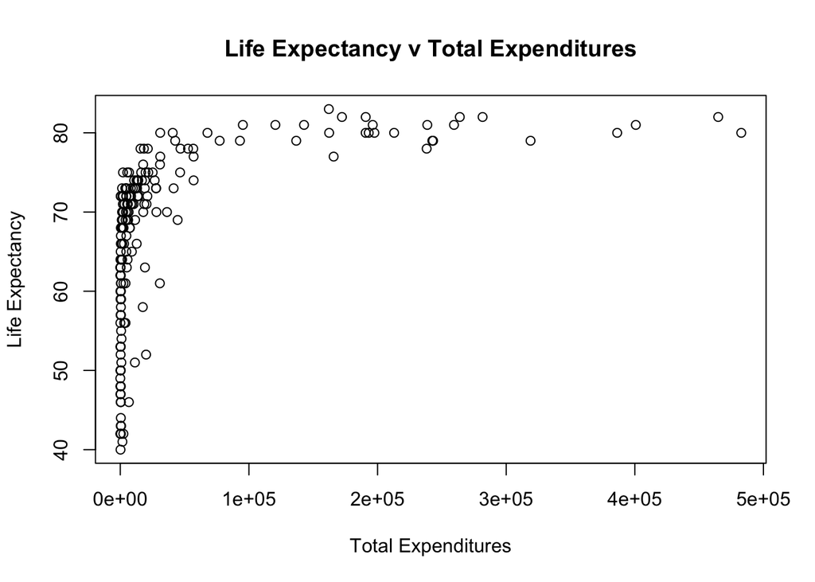

```r
# Linear Model
my_lm <- lm(LifeExp ~ TotExp, who)

# Scatter plot
plot(LifeExp ~ TotExp, who,
     xlab = "Total Expenditures", ylab = "Life Expectancy",
     main = "Life Expectancy v Total Expenditures")
```

$~$

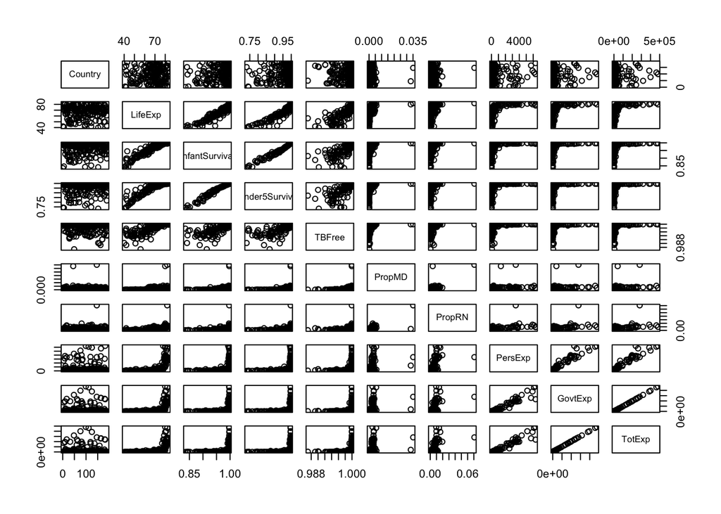

```r
par(mfrow = c(2,2))
plot(who)
```

$~$

```r
# Summary of linear model
summary(my_lm)
```

```
##
## Call:
## lm(formula = LifeExp ~ TotExp, data = who)
##
## Residuals:
##     Min      1Q  Median      3Q     Max
## -24.764  -4.778   3.154   7.116  13.292
##
## Coefficients:
##              Estimate Std. Error t value Pr(>|t|)
## (Intercept) 6.475e+01  7.535e-01  85.933  < 2e-16 ***
## TotExp      6.297e-05  7.795e-06   8.079 7.71e-14 ***
## ---
## Signif. codes:  0 '***' 0.001 '**' 0.01 '*' 0.05 '.' 0.1 ' ' 1
##
## Residual standard error: 9.371 on 188 degrees of freedom
## Multiple R-squared:  0.2577, Adjusted R-squared:  0.2537
## F-statistic: 65.26 on 1 and 188 DF,  p-value: 7.714e-14
```

$~$

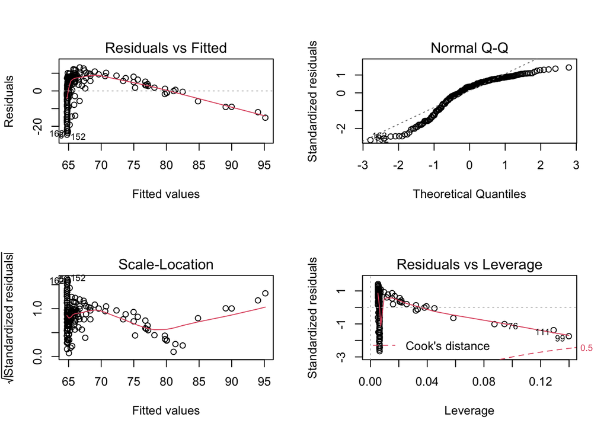

```r
par(mfrow = c(2,2))
plot(my_lm)
```

$~$

#### **F-Statistic and P-Value:** This test if any of the independent variables are related to the Y outcome. If the p-value associated is $\geq$ 0.05 then there is no relationship and if $\leq$ 0.05 then there is at least 1 independent variable related to Y. From the summary we can see that the F-statistic is 65.26 and the p-value is 7.714e-14 which is less than 0.05, meaning there is at least one possible independent variable related to Y. Being that the p-value is relatively small, we can reject the null hypothesis and accept the alternative that the linear model is a better fit for the data.

#### **$R^2$:** This measures how well the model describes our data. With a 0.2577 $R^2$ value, then 25.77% explains the variance in our data set.

#### **Standard Error:** When looking at the standard error you are looking for the variation in the residuals. For this data set the standard error is 9.371 on 188 degrees of freedom.

#### Based on this we cannot asssume that linear regression is met because it doesn’t seem to fully follow a linear trend and there a very low variance ($R^2$) with the data, so there may be other factors that come to play.

$~$

#### 2. Raise life expectancy to the `4.6 power` (i.e., $LifeExp^{4.6}$). Raise total expenditures to the `0.06 power` (nearly a log transform, $TotExp^{.06}$). Plot $LifeExp^{4.6}$ as a function of $TotExp^{.06}$, and r re-run the simple regression model using the transformed variables. Provide and interpret the `F statistics`, `R^2`, `standard error`, and `p-values`. Which model is “better”?

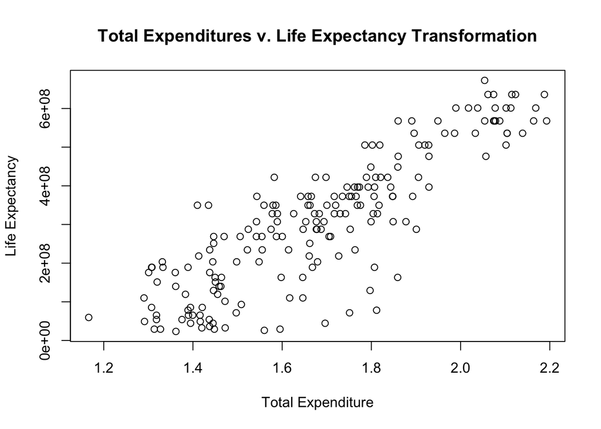

```r
LifeExp46 <- (who$LifeExp ** (4.6))
TotExp06 <- (who$TotExp ** (.06))

plot(TotExp06, LifeExp46,
     xlab = "Total Expenditure",
     ylab = "Life Expectancy",
     main = "Total Expenditures v. Life Expectancy Transformation")
```

$~$

```r
my_lm2 <- lm(LifeExp46 ~ TotExp06, who)
summary(my_lm2)
```

```
##
## Call:
## lm(formula = LifeExp46 ~ TotExp06, data = who)
##
## Residuals:
##        Min         1Q     Median         3Q        Max
## -308616089  -53978977   13697187   59139231  211951764
##
## Coefficients:
##               Estimate Std. Error t value Pr(>|t|)
## (Intercept) -736527910   46817945  -15.73   <2e-16 ***
## TotExp06     620060216   27518940   22.53   <2e-16 ***
## ---
## Signif. codes:  0 '***' 0.001 '**' 0.01 '*' 0.05 '.' 0.1 ' ' 1
##
## Residual standard error: 90490000 on 188 degrees of freedom
## Multiple R-squared:  0.7298, Adjusted R-squared:  0.7283
## F-statistic: 507.7 on 1 and 188 DF,  p-value: < 2.2e-16
```

$~$

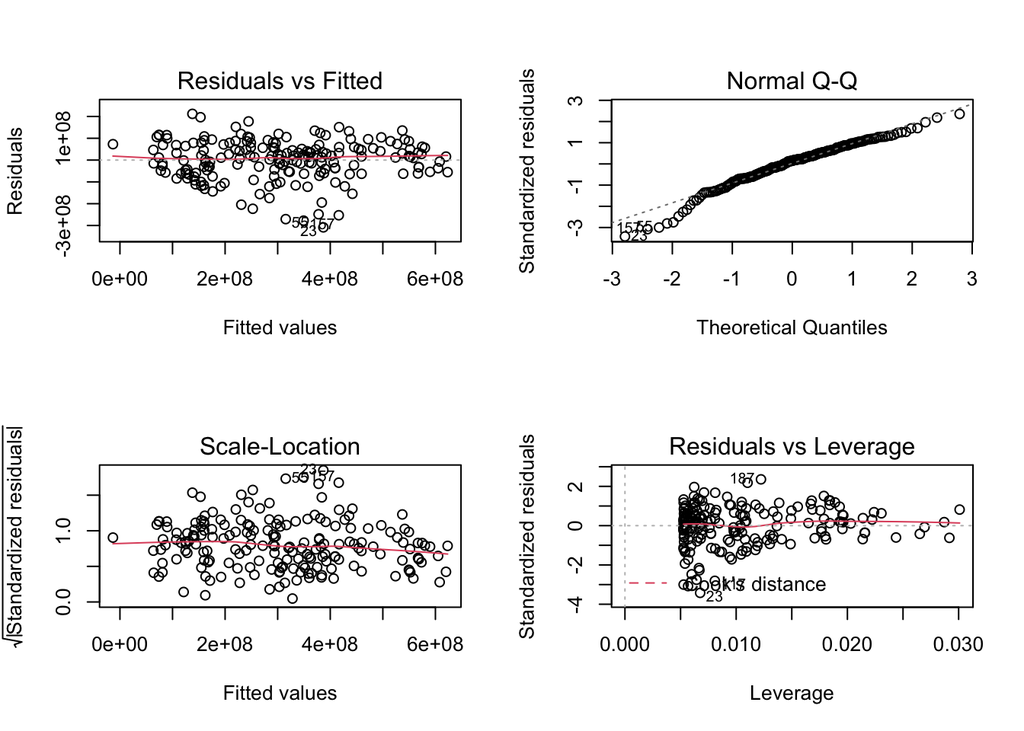

```r
par(mfrow = c(2,2))
plot(my_lm2)
```

$~$

#### **F-Statistic and P-Value:** Similarly to the first model, the F-statistic is 507.7 and the P-value is $<$ 2.2e-16, being that the P-value is small we know this model fits the data well.

#### **$R^2$:** With a 0.7298 $R^2$ value, then 72.98% explains the variance in our data set which is much higher than the first model.

#### **Standard Error:** For this model the standard error is 90490000 on 188 degrees of freedom.

#### Based on this we can asssume that linear regression is met because the plot looks more linear, the $R^2$ value is much higher than the first model and the P-value is still less than 0.05.

$~$

#### 3. Using the results from 3, `forecast life expectancy when TotExp^.06 = 1.5`. Then `forecast life expectancy when TotExp^.06 = 2.5`.

```r
# Key
a <- -736527910
b <- 620060216

# Forecasting life expectancy when TotExp^.06 = 1.5
LifeExp_46 <- a + b * 1.5
LifeExp15 <- exp(log(LifeExp_46) / 4.6)
LifeExp15
```

```
## [1] 63.31153
```

```r
# Forecasting life expectancy when TotExp^.06 = 2.5
LifeExp2_46 <- a + b * 2.5
LifeExp25 <- exp(log(LifeExp2_46) / 4.6)
LifeExp25
```

```
## [1] 86.50645
```

$~$

#### 4. Build the following multiple regression model and interpret the `F Statistics`, `$R^2$`, `standard error`, and `p-values`. How good is the model?

#### `LifeExp = b0 + b1 x PropMd + b2 x TotExp +b3 x PropMD x TotExp`

```r
my_lm3 <- lm(LifeExp ~ PropMD + TotExp + TotExp:PropMD, who)
summary(my_lm3)
```

```
##
## Call:
## lm(formula = LifeExp ~ PropMD + TotExp + TotExp:PropMD, data = who)
##
## Residuals:
##     Min      1Q  Median      3Q     Max
## -27.320  -4.132   2.098   6.540  13.074
##
## Coefficients:
##                 Estimate Std. Error t value Pr(>|t|)
## (Intercept)    6.277e+01  7.956e-01  78.899  < 2e-16 ***
## PropMD         1.497e+03  2.788e+02   5.371 2.32e-07 ***
## TotExp         7.233e-05  8.982e-06   8.053 9.39e-14 ***
## PropMD:TotExp -6.026e-03  1.472e-03  -4.093 6.35e-05 ***
## ---
## Signif. codes:  0 '***' 0.001 '**' 0.01 '*' 0.05 '.' 0.1 ' ' 1
##
## Residual standard error: 8.765 on 186 degrees of freedom
## Multiple R-squared:  0.3574, Adjusted R-squared:  0.3471
## F-statistic: 34.49 on 3 and 186 DF,  p-value: < 2.2e-16
```

$~$

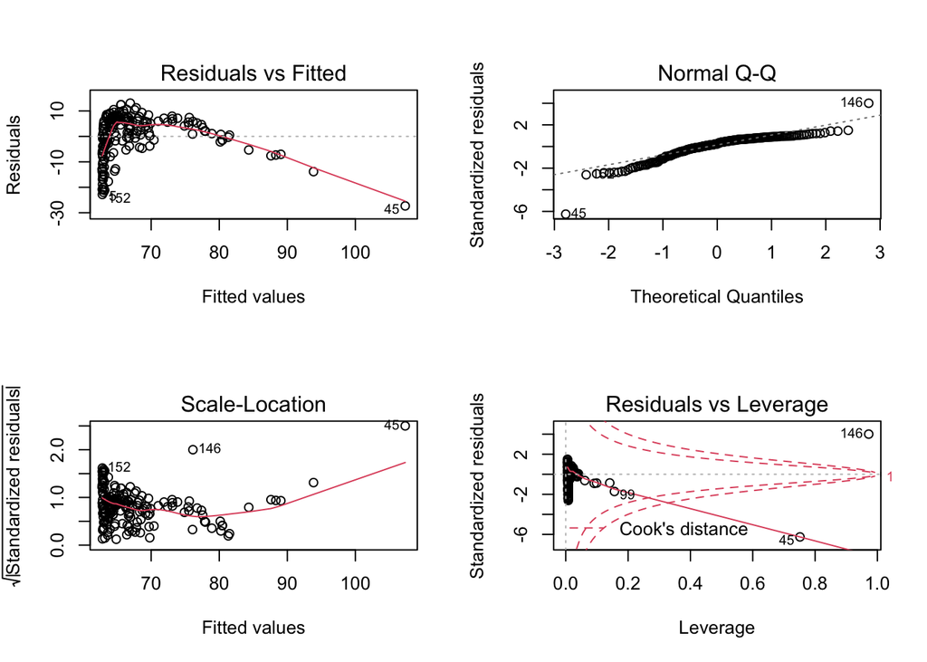

```r
par(mfrow = c(2,2))
plot(my_lm3)
```

$~$

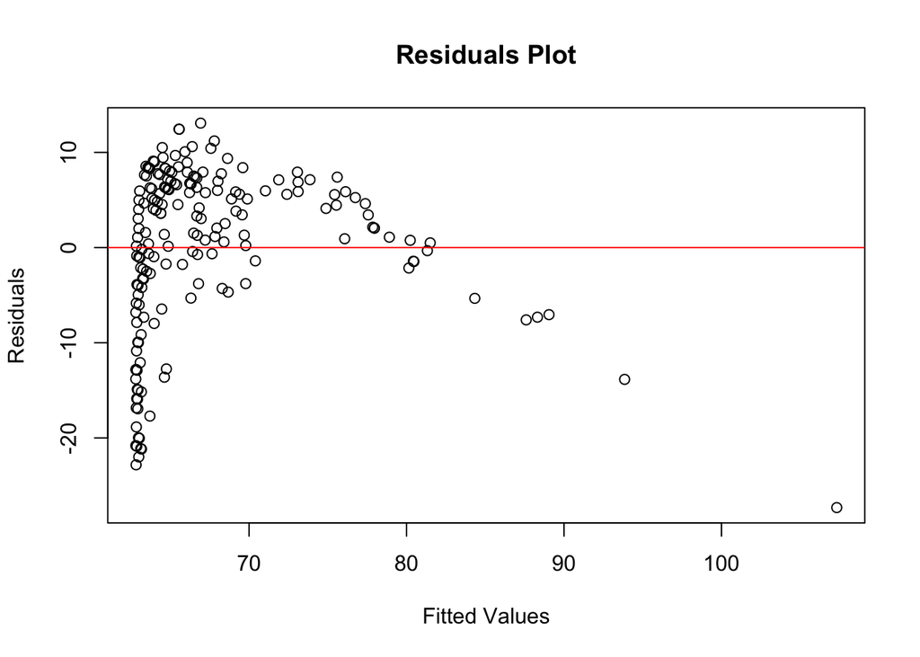

```r
plot(my_lm3$fitted.values, my_lm3$residuals,
     xlab="Fitted Values", ylab="Residuals",
     main="Residuals Plot")
abline(0,0, col = 'red')
```

$~$

#### **F-Statistic and P-Value:** the F-statistic and p-value are still relatively low so we know the model fits the data well.

#### **$R^2$:** Comparing it with the second model, the $R^2$ decreased to 35.74% of variance in the data.

#### **Standard Error:** For this model the standard error is 8.765 on 186 degrees of freedom.

#### Based on the model and plot above, this doesn’t look like it’s normally distributed and the $R^2$ value only accounts for a low amount of variance compared to the second model. Therefore, this model is not a good fit.

$~$

#### 5. `Forecast LifeExp when PropMD = .03 and TotExp = 14`. Does this forecast seem realistic? Why or why not?

```r
# Key
inter <-  62.8
co2 <- 0.00007233
co3 <- 1497
PropMD <- .03
TotExp <- 14

pred_5 <- inter + co2 * TotExp + co3 * PropMD + .006 * 14 * PropMD
pred_5
```

```
## [1] 107.7135
```

$~$

#### This forecast doesn’t seem realistic because it is such a long time for a person’s life expectancy.